# Preparing HMSC model runs

## Species occurrence data processing

Starting from the raw data, I cleaned the data by selecting the native species that were present on both Crozet and Kerguelen islands.

As I explained in a previous document, the data are simple presence records that come from different sampling designs, such that the sites are not homogeneous in terms of surfaces. Since the target resolution of the JSDM predictions are to be of approx 20 x 20m, I discarded all the occurrences of species from sites with surfaces larger than 400m2. The median surface size is 100m2, since a lot of sites are standardized at 10 x 10m. I kept all the sites with inferior surfaces, because the risk of missing an observation decreases with plot size.

Each site is considered to have been visited only once, but in reality some sites overlap a lot (spatially, but then there are different sampling years).

These are all the observations since 2010.

```r
library(tidyverse)
library(Hmsc)
library(V.PhyloMaker)
library(brranching)

theme_set(theme_bw())

# this prepares the community matrices for Crozet and Kerguelen :
source("process_occurrences.R")
```

```r
# look at matrix fill :

# CROZET
dim(cro_com_mat) # 2247 sites, 20 species.
```

```
## [1] 1956   20
```

```r
sum(cro_com_mat) # total number of observations
```

```
## [1] 11200
```

```r
colSums(cro_com_mat) # nb of sites where each plant appears. Cf Limosella australis : remove it.
```

```
##     Pringlea antiscorbutica          Acaena magellanica
##                         488                        1281
##        Agrostis magellanica             Azorella selago
##                        1730                        1277
##     Lycopodium magellanicum            Uncinia compacta
##                         584                         791
##          Galium antarcticum      Phlegmariurus saururus
##                         545                         243
##       Ranunculus biternatus Austroblechnum penna-marina
##                        1182                         723
##     Juncus scheuchzerioides           Crassula moschata
##                         527                          84
##          Leptinella plumosa                  Poa cookii
##                         125                         738
##              Montia fontana      Callitriche antarctica
##                         354                         107
##      Notogrammitis crassior      Deschampsia antarctica
##                          87                         286
##         Limosella australis    Colobanthus kerguelensis
##                           2                          46
```

```r
colSums(cro_com_mat) / nrow(cro_com_mat) *100  # proportion of sites where a plant is observed.
```

```
##     Pringlea antiscorbutica          Acaena magellanica
##                  24.9488753                  65.4907975
##        Agrostis magellanica             Azorella selago
##                  88.4458078                  65.2862986
##     Lycopodium magellanicum            Uncinia compacta
##                  29.8568507                  40.4396728
##          Galium antarcticum      Phlegmariurus saururus
##                  27.8629857                  12.4233129
##       Ranunculus biternatus Austroblechnum penna-marina
##                  60.4294479                  36.9631902
##     Juncus scheuchzerioides           Crassula moschata
##                  26.9427403                   4.2944785
##          Leptinella plumosa                  Poa cookii
##                   6.3905930                  37.7300613
##              Montia fontana      Callitriche antarctica
##                  18.0981595                   5.4703476
##      Notogrammitis crassior      Deschampsia antarctica
##                   4.4478528                  14.6216769
##         Limosella australis    Colobanthus kerguelensis
##                   0.1022495                   2.3517382
```

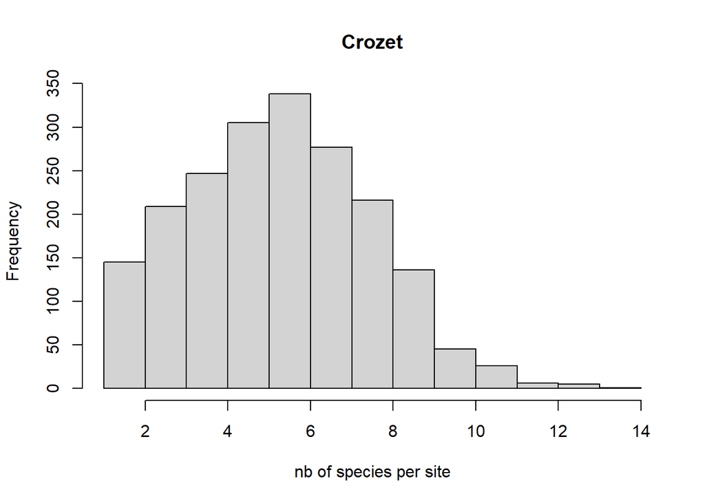

```r
rowSums(cro_com_mat) %>% hist(., main = "Crozet", xlab = "nb of species per site")
```

```r
# KERGUELEN
dim(ker_com_mat) # " 2646 sites, 20 species"
```

```
## [1] 2450   20
```

```r
sum(ker_com_mat) # total number of observations
```

```
## [1] 9086
```

```r
colSums(ker_com_mat) # nb of sites where each plant appears
```

```
##           Crassula moschata          Leptinella plumosa
##                         143                         454
##       Ranunculus biternatus              Montia fontana
##                        1147                         572
##      Callitriche antarctica          Acaena magellanica
##                         143                        1790
##        Agrostis magellanica     Juncus scheuchzerioides
##                         940                         511
##             Azorella selago          Galium antarcticum
##                        1161                         447
## Austroblechnum penna-marina      Deschampsia antarctica
##                         312                         365
##    Colobanthus kerguelensis                  Poa cookii
##                         156                         126
##     Pringlea antiscorbutica     Lycopodium magellanicum
##                         430                         168
##         Limosella australis            Uncinia compacta
##                          26                         138
##      Phlegmariurus saururus      Notogrammitis crassior
##                          44                          13
```

```r
colSums(ker_com_mat) / nrow(ker_com_mat) *100 # proportion of sites where a plant is observed.
```

```
##           Crassula moschata          Leptinella plumosa
##                   5.8367347                  18.5306122
##       Ranunculus biternatus              Montia fontana
##                  46.8163265                  23.3469388
##      Callitriche antarctica          Acaena magellanica
##                   5.8367347                  73.0612245
##        Agrostis magellanica     Juncus scheuchzerioides
##                  38.3673469                  20.8571429
##             Azorella selago          Galium antarcticum
##                  47.3877551                  18.2448980
## Austroblechnum penna-marina      Deschampsia antarctica
##                  12.7346939                  14.8979592
##    Colobanthus kerguelensis                  Poa cookii
##                   6.3673469                   5.1428571
##     Pringlea antiscorbutica     Lycopodium magellanicum
##                  17.5510204                   6.8571429
##         Limosella australis            Uncinia compacta
##                   1.0612245                   5.6326531
##      Phlegmariurus saururus      Notogrammitis crassior
##                   1.7959184                   0.5306122
```

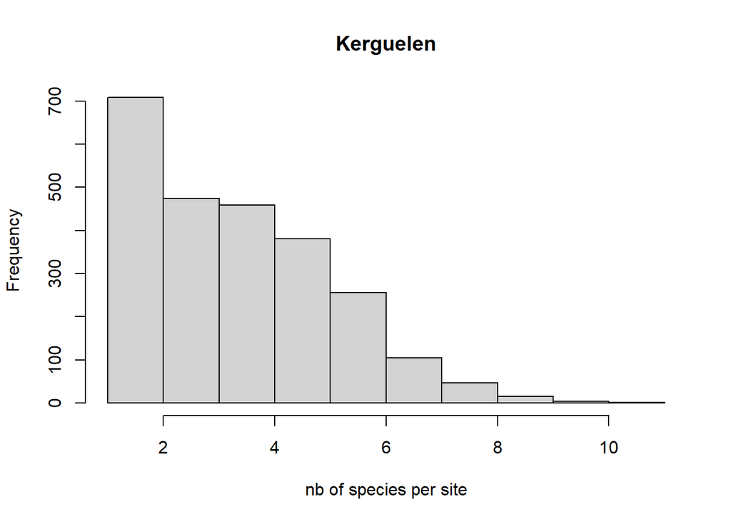

```r
rowSums(ker_com_mat) %>% hist(., main = "Kerguelen", xlab = "nb of species per site")
```

Questions :

- is there a threshold under which we consider a species to be too rare for the models to cope with ?
- should we decide to remove a species, we should remove it in both islands, even if it’s only rare in one of them ?

## Traits

I tried to get some trait data from the TRY database, but I ran into a series of problems, and in the end I don’t think we’ll be able to incorporate traits in this way. The problem is the TRY database only allows to download 20 traits at a time for a given species, so you have to know which traits you want. I tried to download the traits that have been measured the most over the whole database and were meaningful for the list of native plants, but in our case, they don’t overlap very much. This means we would have to drop species out of the analysis. I’d rather try and compensate for this with the phylogeny data, rather than put too much weight on traits that aren’t even necessarily that relevant to the question we want to ask.

In any case, if we really need to incorporate traits, I’m going to need some help and talk with specialists from either TRY or ASICS plant traits, I can’t solve this alone…

## Phylogenies

In the end, I chose a method which seems to be the easiest way to do things : I accessed a huge Tree of Life reference phylogeny for plants (Qian, H. & Jin, Y. (2016) Journal of Plant Ecology), it’s supposed to be the most up-to-date one there is. Then I simply pruned it to keep only the species I’m interested in. Claudine Montgelard said it should be OK. The thing that bothers me is that it’s a bit of a black box to me in terms of how this tree was built, but it seems to be legit and widely used so… I think it should be good enough.

The discussion I had with Claudine was useful to help me understand some of the issues, but in the end the tools she suggested turned out to be unpractical : mostly online services, with options to tick based on her recommendations (and would have been tough for me to defend in a publication). Plus I did try and submit a request, but it never came back to me.

I have scripts to extract gene/protein sequences and build trees with those, but this requires to take many decisions I don’t really trust myself to do. This was what I went to see Claudine for in the 1st place, but she didn’t provide any straightforward answers to them.

Long story short : I have a tree, it’s probably somewhat rough but I think it’ll do the job. But if we’re not satisfied, we can decide to dig further in the directions mentioned above.

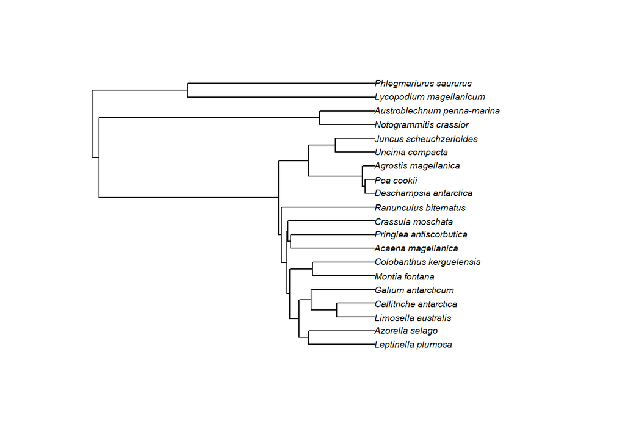

```r
load("../data/traits_trees/phylomaker_tree.RData")
plot(result[[3]], cex = 0.6)
```

```r
result$species.list
```

|  | species | genus | family | status |
| --- | --- | --- | --- | --- |
| 1 | acaena_magellanica | acaena | rosaceae | prune |
| 2 | agrostis_magellanica | agrostis | poaceae | bind |
| 3 | austroblechnum_penna-marina | austroblechnum | blechnaceae | bind |
| 4 | azorella_selago | azorella | apiaceae | bind |
| 5 | callitriche_antarctica | callitriche | plantaginaceae | bind |
| 6 | colobanthus_kerguelensis | colobanthus | caryophyllaceae | bind |
| 7 | crassula_moschata | crassula | crassulaceae | prune |
| 8 | deschampsia_antarctica | deschampsia | poaceae | prune |
| 9 | galium_antarcticum | galium | rubiaceae | bind |
| 10 | juncus_scheuchzerioides | juncus | juncaceae | bind |

[output cut: 10 more lines]

## Temperature layers and downscaling